# 15 – Lecture sample code

Elizabeth Pankratz

9–10 February, 2026

## RQ

- Do differences in test scores between study conditions differ by the note-taking medium used?

## Phase 1: Identify the relevant variables

```r
library(tidyverse)
library(interactions)
library(emmeans)

notes <- read_csv('https://uoepsy.github.io/data/laptop_vs_longhand.csv')
```

```r
names(notes)
```

```
## [1] "test_score" "medium"     "study"
```

RQ1: Do differences in test scores between study conditions differ by the note-taking medium used?

- test scores: `test_score`
- study conditions: `study`
- note-taking medium: `medium`

Outcome: `test_score`

Predictors: `study`, `medium`

## Phase 1: Data tidying (e.g., missingness? factor levels?)

```r
summary(notes)
```

```
##    test_score       medium             study
##  Min.   :44.86   Length:160         Length:160
##  1st Qu.:53.63   Class :character   Class :character
##  Median :59.27   Mode  :character   Mode  :character
##  Mean   :63.42
##  3rd Qu.:68.05
##  Max.   :94.32
```

```r
is.na(notes) |> table()
```

```
##
## FALSE
##   480
```

^ No NAs anywhere!

Convert to factors, and, assuming treatment coding, set reference levels:

```r
notes <- notes |>
  mutate(
    medium = factor(medium, levels = c('Laptop', 'Longhand')),
    study = factor(study, levels = c('No', 'Minimal', 'Moderate', 'Extensive'))
  )
```

## Phase 1: Get summary statistics for the relevant variables

```r
psych::describe(notes$test_score)
```

|  | vars | n | mean | sd | median | trimmed | mad | min | max | range | skew | kurtosis | se |
| --- | --- | --- | --- | --- | --- | --- | --- | --- | --- | --- | --- | --- | --- |
| X1 | 1 | 160 | 63.41875 | 13.93684 | 59.26626 | 61.95923 | 8.586668 | 44.85646 | 94.32085 | 49.46439 | 0.8832146 | -0.5150218 | 1.101804 |

```r
table(notes$medium)
```

```
##
##   Laptop Longhand
##       80       80
```

```r
table(notes$study)
```

```
##
##        No   Minimal  Moderate Extensive
##        40        40        40        40
```

## Phase 1: Plot each relevant variable individually

Test scores:

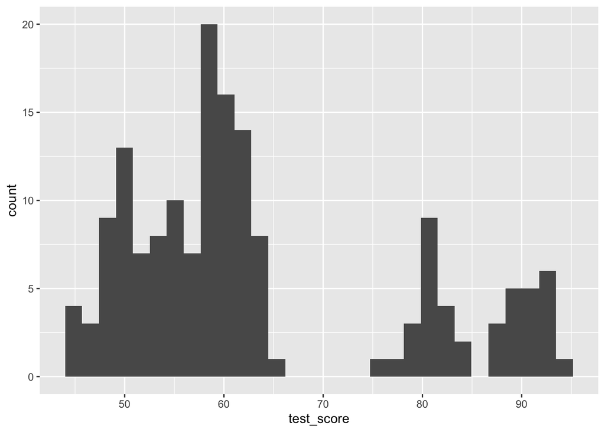

```r
notes |>
  ggplot(aes(x = test_score)) +
  geom_histogram()
```

Study:

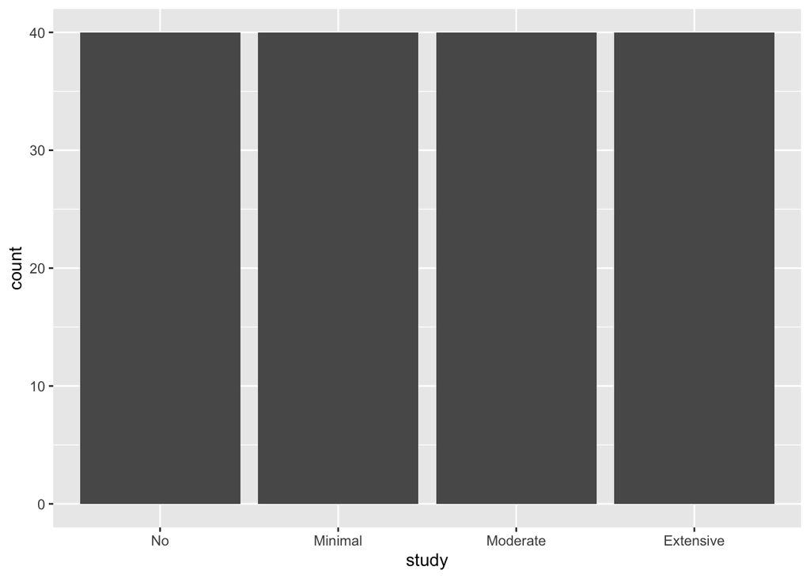

```r
notes |>
  ggplot(aes(x = study)) +
  geom_bar()
```

^ boring.

Medium:

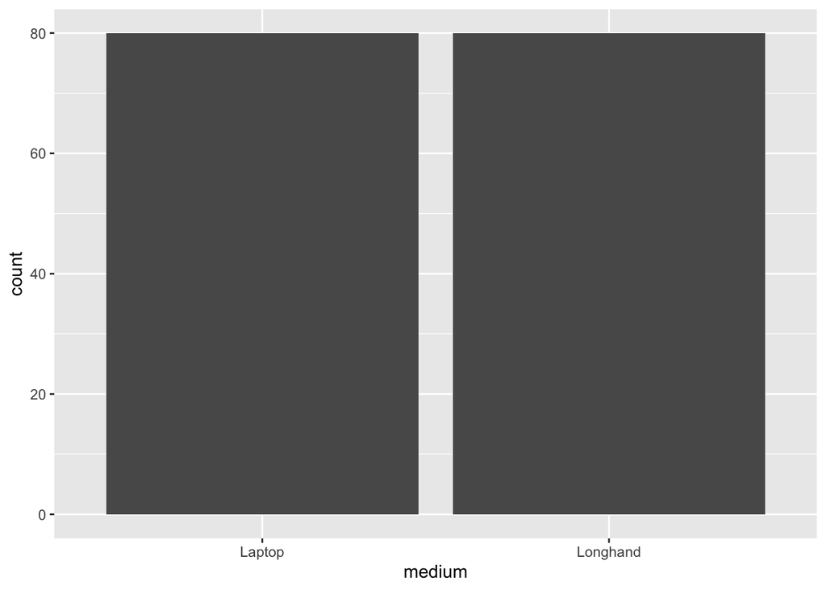

```r
notes |>
  ggplot(aes(x = medium)) +
  geom_bar()
```

^ boring.

## Phase 1: Plot the relevant variables together

Violin plot:

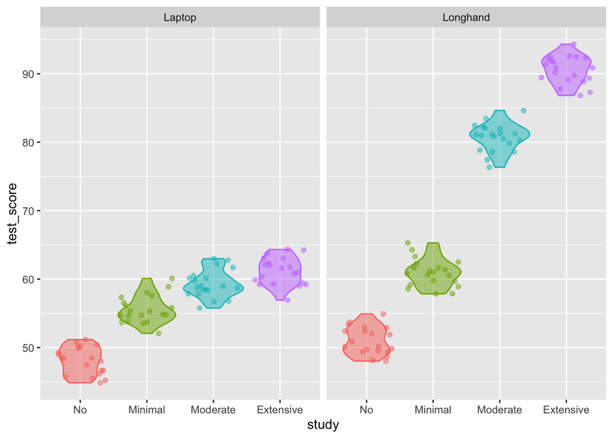

```r
notes |>
  ggplot(aes(x = study, y = test_score, colour = study, fill = study)) +
  geom_violin(alpha = 0.5) +
  geom_jitter(alpha = 0.5) +
  facet_wrap(~ medium) +
  theme(legend.position = 'none')
```

Boxplot:

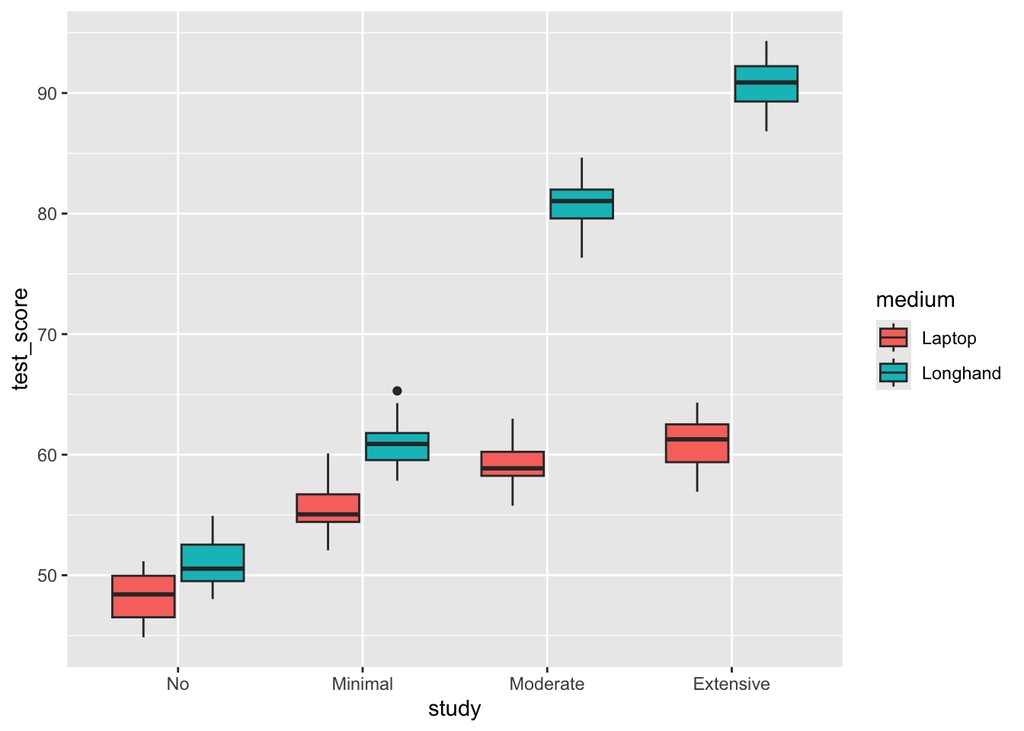

```r
notes |>
  ggplot(aes(x = study, y = test_score, fill = medium)) +
  geom_boxplot()
```

## Phase 1: Set up categorical predictors (e.g., what a priori coding scheme?)

We’ll just use treatment coding.

Check contrasts:

```r
contrasts(notes$medium)
```

```
##          Longhand
## Laptop          0
## Longhand        1
```

^ Laptop is reference level.

```r
contrasts(notes$study)
```

```
##           Minimal Moderate Extensive
## No              0        0         0
## Minimal         1        0         0
## Moderate        0        1         0
## Extensive       0        0         1
```

^ “No” is reference level. We have three dummy variables which compare “No” to each of the non-reference levels individually.

## Phase 1: Set up continuous predictors (e.g., any transformations?)

NA

## Phase 1: Decide whether the RQ requires an interaction model

RQ1: Do **differences** in test scores between study conditions **differ** by the note-taking medium used?

Yes! Because we’re asking about whether differences differ, we need an interaction model.

## Phase 1: Think what the model coefficients might look like

Formulate mathematical model expression:

```
$$
\text{test_score} = \beta_0 +
(\beta_1 \cdot \text{M}) +
(\beta_2 \cdot \text{S}_{\text{Minimal}}) +
(\beta_3 \cdot \text{S}_{\text{Moderate}}) +
(\beta_4 \cdot \text{S}_{\text{Extensive}}) + \\
(\beta_5 \cdot \text{M} \cdot \text{S}_{\text{Minimal}}) +
(\beta_6 \cdot \text{M} \cdot \text{S}_{\text{Moderate}}) +
(\beta_7 \cdot \text{M} \cdot \text{S}_{\text{Extensive}}) +
\epsilon
$$
```

$$\text{test_score} = \beta_0 +
(\beta_1 \cdot \text{M}) +
(\beta_2 \cdot \text{S}_{\text{Minimal}}) +
(\beta_3 \cdot \text{S}_{\text{Moderate}}) +
(\beta_4 \cdot \text{S}_{\text{Extensive}}) + \\
(\beta_5 \cdot \text{M} \cdot \text{S}_{\text{Minimal}}) +
(\beta_6 \cdot \text{M} \cdot \text{S}_{\text{Moderate}}) +
(\beta_7 \cdot \text{M} \cdot \text{S}_{\text{Extensive}}) +
\epsilon$$

^ We should expect eight coefficients.

Check that this number of interaction terms is right:

$$(r-1) \times (c-1) \\
(2-1) \times (4-1) \\
1 \times 3 \\
3$$
^ Yep!

Model coefficients’ meanings and, based on the plots, probable values/signs (pos or neg):

- **$\beta_0$, Intercept:**
  - **meaning:** estimated mean test score when `medium = Laptop` and `study = No`
  - **value:** probably just below 50
- **$\beta_1$, effect of medium:**
  - **meaning:** specifically when `study = No`, how do test scores change between `medium = Laptop` and `medium = Longhand`?
  - **value:** probably small and positive
- **$\beta_2$, effect of $\text{study}_{\text{Minimal}}$:**
  - **meaning:** specifically when `medium = Laptop`, how do test scores change between `study = No` and `study = Minimal`?
  - **value:** probably about twice the value of $\beta_1$, positive
- **$\beta_3$, effect of $\text{study}_{\text{Moderate}}$:**
  - **meaning:** specifically when `medium = Laptop`, how do test scores change between `study = No` and `study = Moderate`?
  - **value:** a bit bigger than $\beta_2$, positive
- **$\beta_4$, effect of $\text{study}_{\text{Extensive}}$:**
  - **meaning:** specifically when `medium = Laptop`, how do test scores change between `study = No` and `study = Extensive`?
  - **value:** a bit bigger than $\beta_3$, positive
- **$\beta_5$, interaction between medium and $\text{study}_{\text{Minimal}}$:**
  - **meaning:** how does the difference between `study = No` and `study = Minimal` change, when we move from `medium = Laptop` to `medium = Longhand`?
  - **value:** probably close to zero (the difference between `No` and `Minimal` looks basically the same for both `Laptop` and `Longhand`)
- **$\beta_6$, interaction between medium and $\text{study}_{\text{Moderate}}$:**
  - **meaning:** how does the difference between `study = No` and `study = Moderate` change, when we move from `medium = Laptop` to `medium = Longhand`?
  - **value:** probably fairly large and positive (the jump from `No` to `Moderate` is bigger for `Longhand` than for `Laptop`, so we need a big positive adjustment)
- **$\beta_7$, interaction between medium and $\text{study}_{\text{Extensive}}$:**
  - **meaning:** how does the difference between `study = No` and `study = Extensive` change, when we move from `medium = Laptop` to `medium = Longhand`?
  - **value:** probably even larger than $\beta_6$ and positive (the jump from `No` to `Extensive` is much bigger for `Longhand` than it is for `Laptop`, so we need a real big positive adjustment)

## Phase 1: Formally state null and alternative hypotheses

RQ1: Do **differences** in test scores between study conditions **differ** by the note-taking medium used?

In words:

- H0 would state that differences in test scores between study conditions **do not differ** by the note-taking medium used.
- If H0 is true, all of the interaction terms are equal to zero.
- If any of the interaction terms are significant, then we can reject H0.

Formally:

```
$$
H_{0} : \text{all } \beta_j = 0 \text{ for } j = 5, 6, 7 \\
H_{1} : \text{any } \beta_j \neq 0 \text{ for } j = 5, 6, 7
$$
```

$$H_{0} : \text{all } \beta_j = 0 \text{ for } j = 5, 6, 7 \\
H_{1} : \text{any } \beta_j \neq 0 \text{ for } j = 5, 6, 7$$

## Phase 2: Fit the linear model to the data

```r
notes_mdl <- lm(test_score ~ medium * study, data = notes)
```

or

```r
notes_mdl <- lm(test_score ~ medium + study + medium:study, data = notes)
```

Quick check that it worked:

```r
notes_mdl
```

```
##
## Call:
## lm(formula = test_score ~ medium + study + medium:study, data = notes)
##
## Coefficients:
##                   (Intercept)                 mediumLonghand
##                         48.12                           2.90
##                  studyMinimal                  studyModerate
##                          7.45                          11.18
##                studyExtensive    mediumLonghand:studyMinimal
##                         13.04                           2.44
##  mediumLonghand:studyModerate  mediumLonghand:studyExtensive
##                         18.49                          26.52
```

## Phase 3: Check model assumptions

**Linearity of association:** We can assume this is fulfilled because we have categorical predictors.

**Independence of errors:** We can assume this is fulfilled because we have one observation per person (i.e., a between-participant design).

**Normality of errors:** Check using Q-Q plot.

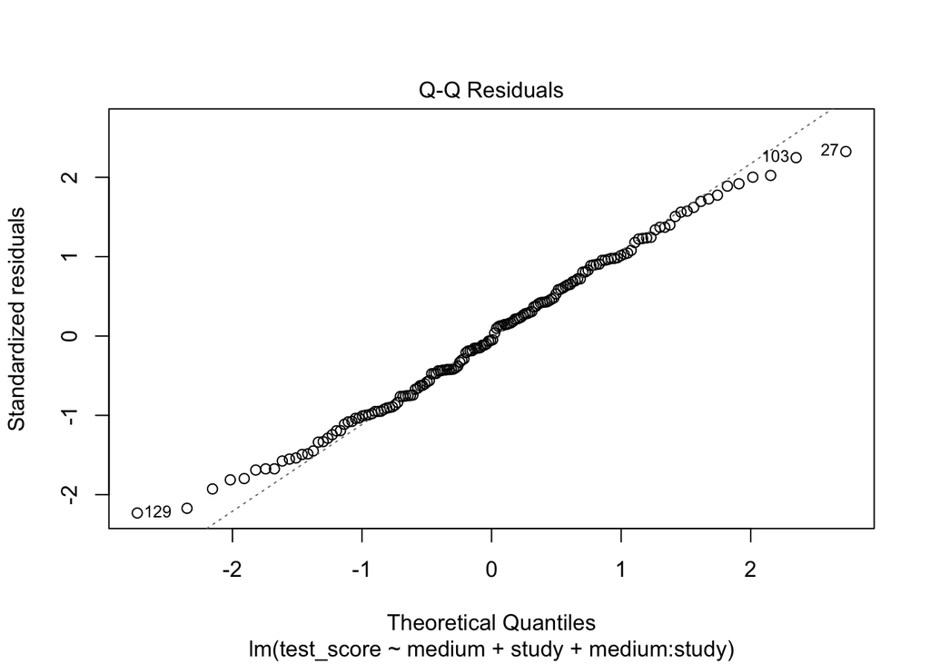

```r
plot(notes_mdl, which = 2)
```

^ Looks fine! Good match to the diagonal.

**Equal variance of errors:** Check using a plot of residuals vs. fitted values:

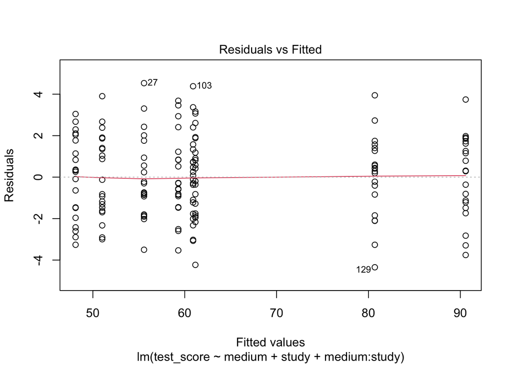

```r
plot(notes_mdl, which = 1)
```

^ Looks fine: good horizontal line, and similar spread of residuals for all fitted values.

## Phase 3: Run diagnostics for multicollinearity

- We use `type = 'predictor'` to tell `vif()` that there’s an interaction.

```r
car::vif(notes_mdl, type = 'predictor')
```

```
## GVIFs computed for predictors
```

|  | GVIF | Df | GVIF^(1/(2*Df)) | Interacts With | Other Predictors |
| --- | --- | --- | --- | --- | --- |
| medium | 1 | 7 | 1 | study | -- |
| study | 1 | 7 | 1 | medium | -- |

All 1, so not a cause for worry.

## Phase 3: Interpret the model estimates

```r
summary(notes_mdl)
```

```
##
## Call:
## lm(formula = test_score ~ medium + study + medium:study, data = notes)
##
## Residuals:
##     Min      1Q  Median      3Q     Max
## -4.3485 -1.4764 -0.1018  1.4039  4.5321
##
## Coefficients:
##                               Estimate Std. Error t value Pr(>|t|)
## (Intercept)                    48.1200     0.4472 107.600  < 2e-16 ***
## mediumLonghand                  2.9000     0.6325   4.585 9.41e-06 ***
## studyMinimal                    7.4500     0.6325  11.779  < 2e-16 ***
## studyModerate                  11.1800     0.6325  17.677  < 2e-16 ***
## studyExtensive                 13.0400     0.6325  20.618  < 2e-16 ***
## mediumLonghand:studyMinimal     2.4400     0.8944   2.728  0.00712 **
## mediumLonghand:studyModerate   18.4900     0.8944  20.672  < 2e-16 ***
## mediumLonghand:studyExtensive  26.5200     0.8944  29.650  < 2e-16 ***
## ---
## Signif. codes:  0 '***' 0.001 '**' 0.01 '*' 0.05 '.' 0.1 ' ' 1
##
## Residual standard error: 2 on 152 degrees of freedom
## Multiple R-squared:  0.9803, Adjusted R-squared:  0.9794
## F-statistic:  1081 on 7 and 152 DF,  p-value: < 2.2e-16
```

- `Intercept`:
  - estimated mean test score when `medium = Laptop` and `study = No`
- `mediumLonghand`:
  - specifically when `study = No`, test scores change by 2.9 points when we go from `medium = Laptop` to `medium = Longhand`
- `studyMinimal`:
  - specifically when `medium = Laptop`, test scores change by 7.5 points when we go from `study = No` to `study = Minimal`
- `studyModerate`:
  - specifically when `medium = Laptop`, test scores change by 11.2 points when we go from `study = No` to `study = Moderate`
- `studyExtensive`:
  - specifically when `medium = Laptop`, test scores change by 13.0 points when we go from `study = No` to `study = Extensive`
- `mediumLonghand:studyMinimal`:
  - when we move from `medium = Laptop` to `medium = Longhand`, the difference between `study = No` and `study = Minimal` changes by 2.4 points.
- `mediumLonghand:studyModerate`:
  - when we move from `medium = Laptop` to `medium = Longhand`, the difference between `study = No` and `study = Moderate` changes by 18.5 points.
- `mediumLonghand:studyExtensive`:
  - when we move from `medium = Laptop` to `medium = Longhand`, the difference between `study = No` and `study = Extensive` changes by 26.5 points.

## Phase 3: Get estimated marginal means

```r
notes_emm <- emmeans(notes_mdl, ~ medium * study)
notes_emm
```

```
##  medium   study     emmean    SE  df lower.CL upper.CL
##  Laptop   No          48.1 0.447 152     47.2     49.0
##  Longhand No          51.0 0.447 152     50.1     51.9
##  Laptop   Minimal     55.6 0.447 152     54.7     56.5
##  Longhand Minimal     60.9 0.447 152     60.0     61.8
##  Laptop   Moderate    59.3 0.447 152     58.4     60.2
##  Longhand Moderate    80.7 0.447 152     79.8     81.6
##  Laptop   Extensive   61.2 0.447 152     60.3     62.0
##  Longhand Extensive   90.6 0.447 152     89.7     91.5
##
## Confidence level used: 0.95
```

## Phase 3: Plot estimated marginal means

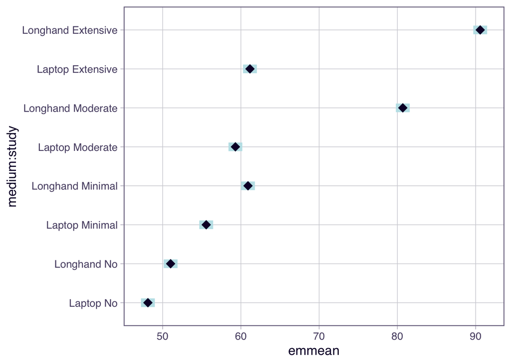

```r
plot(notes_emm)
```

## Phase 3: Compute simple slopes/simple effects

```r
pairs(
  notes_emm,
  simple = 'medium'
)
```

```
## study = No:
##  contrast          estimate    SE  df t.ratio p.value
##  Laptop - Longhand    -2.90 0.632 152  -4.585 <0.0001
##
## study = Minimal:
##  contrast          estimate    SE  df t.ratio p.value
##  Laptop - Longhand    -5.34 0.632 152  -8.443 <0.0001
##
## study = Moderate:
##  contrast          estimate    SE  df t.ratio p.value
##  Laptop - Longhand   -21.39 0.632 152 -33.821 <0.0001
##
## study = Extensive:
##  contrast          estimate    SE  df t.ratio p.value
##  Laptop - Longhand   -29.42 0.632 152 -46.517 <0.0001
```

```r
pairs(
  notes_emm,
  simple = 'study'
)
```

```
## medium = Laptop:
##  contrast             estimate    SE  df t.ratio p.value
##  No - Minimal            -7.45 0.632 152 -11.779 <0.0001
##  No - Moderate          -11.18 0.632 152 -17.677 <0.0001
##  No - Extensive         -13.04 0.632 152 -20.618 <0.0001
##  Minimal - Moderate      -3.73 0.632 152  -5.898 <0.0001
##  Minimal - Extensive     -5.59 0.632 152  -8.839 <0.0001
##  Moderate - Extensive    -1.86 0.632 152  -2.941  0.0196
##
## medium = Longhand:
##  contrast             estimate    SE  df t.ratio p.value
##  No - Minimal            -9.89 0.632 152 -15.637 <0.0001
##  No - Moderate          -29.67 0.632 152 -46.912 <0.0001
##  No - Extensive         -39.56 0.632 152 -62.550 <0.0001
##  Minimal - Moderate     -19.78 0.632 152 -31.275 <0.0001
##  Minimal - Extensive    -29.67 0.632 152 -46.912 <0.0001
##  Moderate - Extensive    -9.89 0.632 152 -15.637 <0.0001
##
## P value adjustment: tukey method for comparing a family of 4 estimates
```

## Phase 3: Plot simple slopes/simple effects

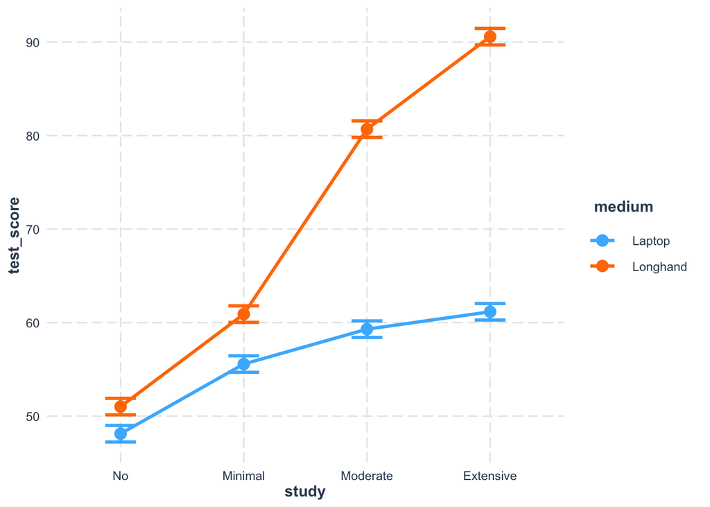

```r
cat_plot(
  notes_mdl,
  pred = 'study',
  modx = 'medium',
  geom = 'line'
)
```

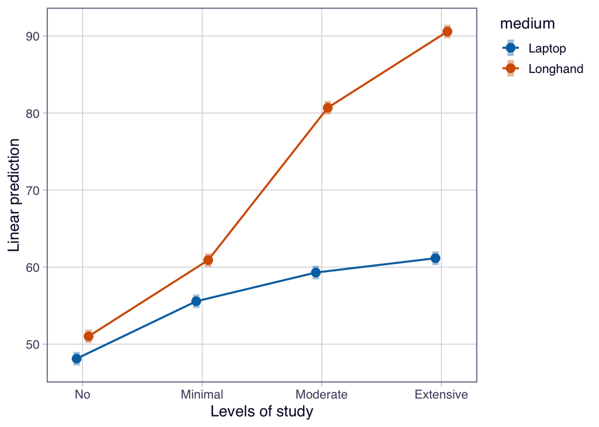

```r
emmip(notes_emm, formula = medium ~ study, CIs = TRUE)
```

## Phase 3: Create and test manual contrasts

NA

## Phase 3: Create and test interactions between manual contrasts

NA

## Phase 3: Write up your analysis (in this week’s labs!)

NA